# Task 12

Cody Jenson

2/25/2021

## Loading and Exploring the Data

```r
library(devtools)
library(ourworldindata)
library(tidyverse)
```

```r
library(mosaic)
library(ggrepel)
```

```r
fh <- financing_healthcare %>%
  filter(!is.na(child_mort)) %>%
  filter(!is.na(continent))

fh2 <- fh %>%
  filter(!is.na(health_exp_total)) %>%
  select(c(year, country, continent, health_exp_total, child_mort))

fh3 <- fh %>%
  filter(!is.na(gdp)) %>%
  select(c(year, country, continent, gdp, child_mort))

fh4 <- fh %>%
  filter(!is.na(health_exp_public)) %>%
  filter(!is.na(health_exp_private)) %>%
  select(c(year, country, continent, health_exp_public, health_exp_private, child_mort))
fh4 <- fh4 %>%
  mutate(more_public = (health_exp_public/health_exp_private) > 1)

fh5 <- fh3 %>%
  filter(continent == "Africa")
```

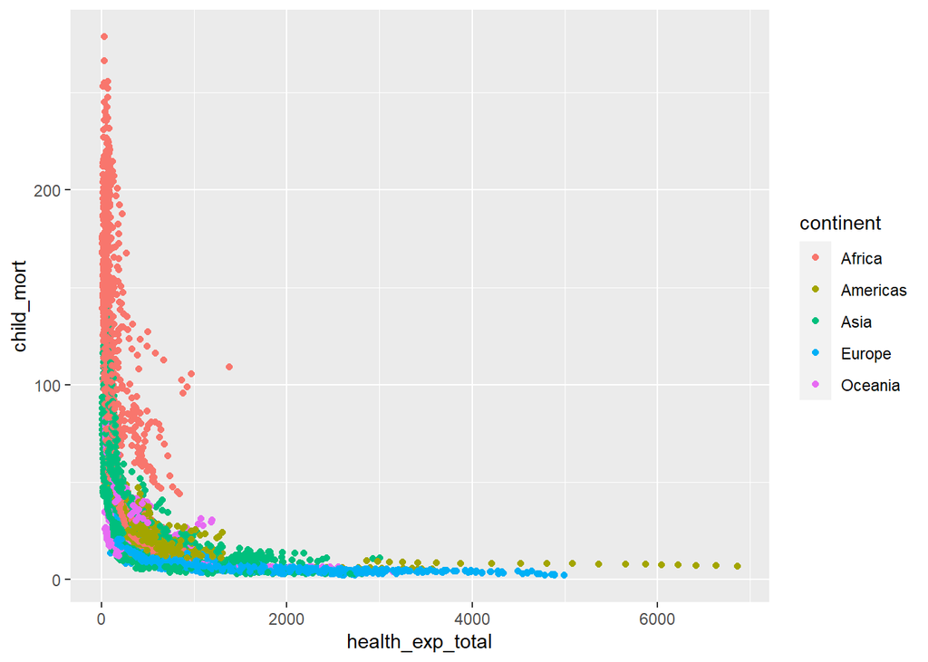

```r
ggplot(fh2) +
  geom_point(aes(x = health_exp_total, y = child_mort, color = continent))
```

very clear correlation, not exaclty linear but very strong. Athough spending more than 2000 on healthcare really doesn’t seem to have much of an effect, maybe up to 3000.

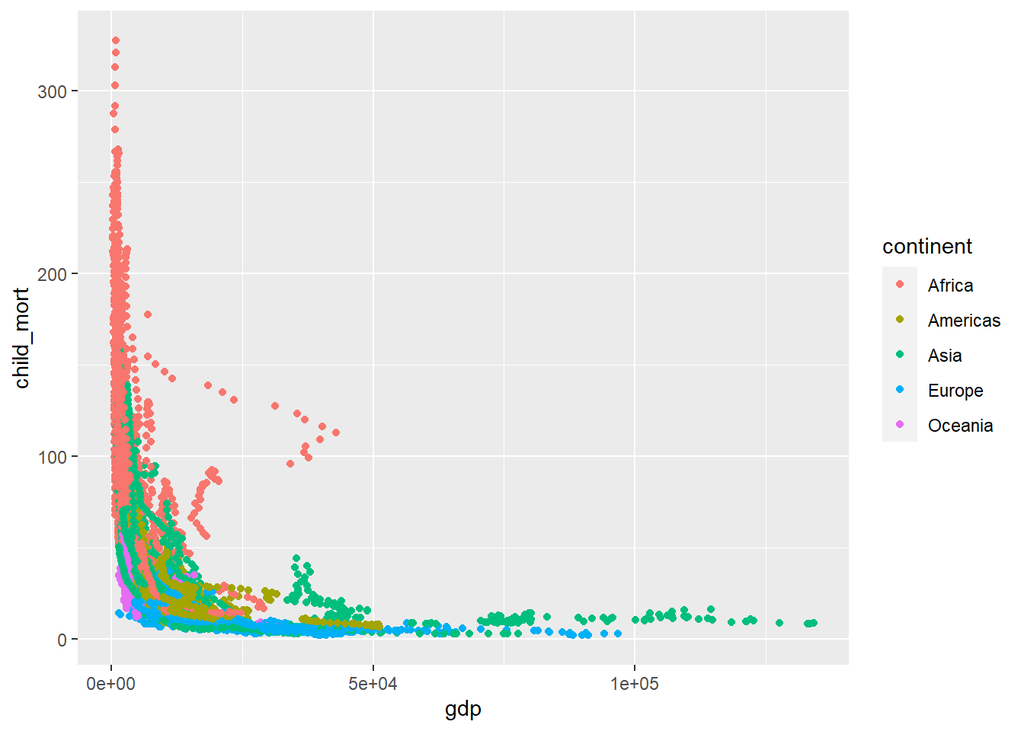

```r
ggplot(fh3) +
  geom_point(aes(x = gdp, y = child_mort, color = continent))
```

We see a strong correlation, and we also see that there is some clear seperation in where continents line up. there are some african countries that are deviating pretty strongly though.

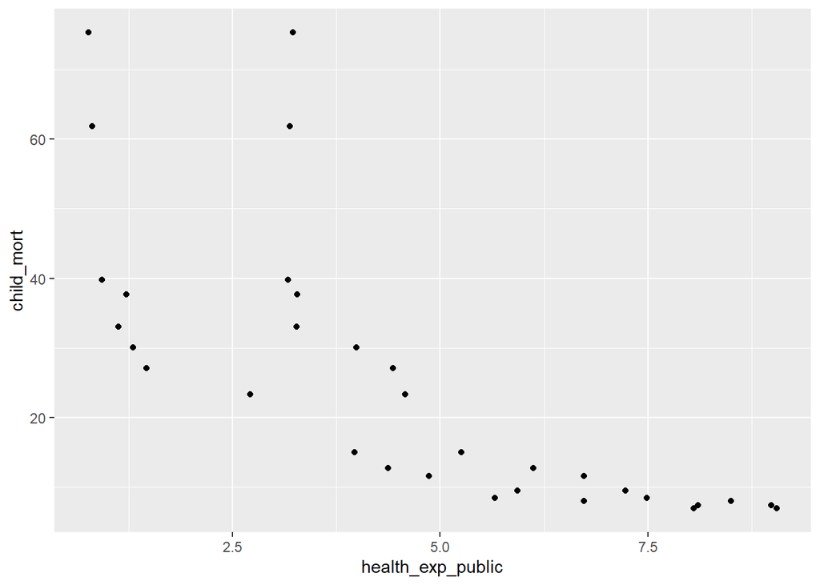

```r
ggplot(fh4) +
  geom_point(aes(x = health_exp_public, y = child_mort)) +
  geom_point(aes(x = health_exp_private, y = child_mort))
```

This graph is not helpful at all. Viewing the adjustments made to fh4, we see that the only instances with both of these to compare in the USA and private is higher in all cases.

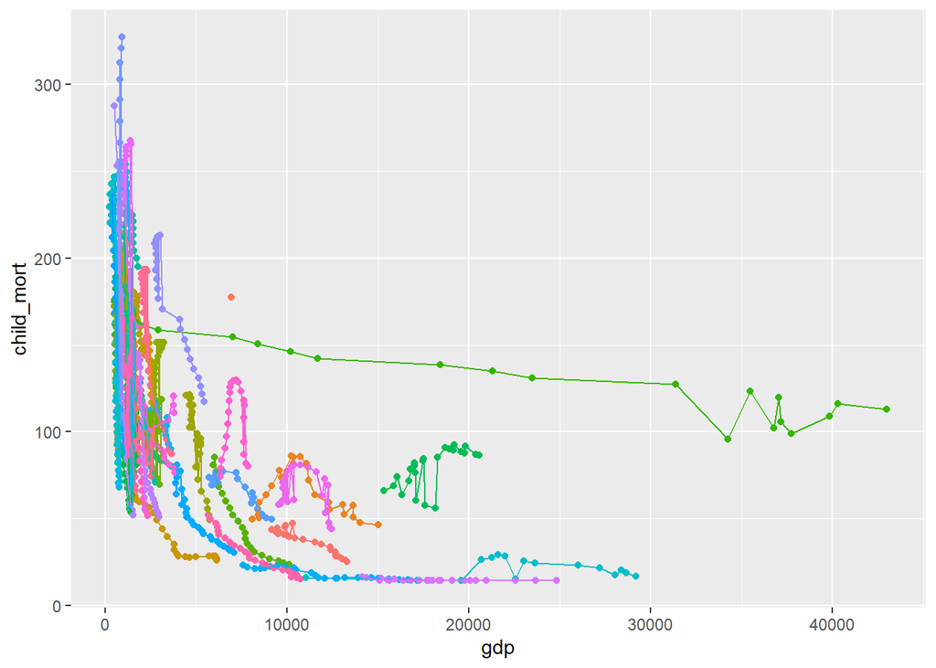

```r
ggplot(fh5, aes(x = gdp, y = child_mort, color = country)) +
  geom_point() +
  geom_line() +
  theme(legend.position = "none")
```

```r
favstats(fh5$gdp ~ fh5$country)
```

```
##                     fh5$country        min         Q1     median         Q3
## 1                       Algeria  9172.8649  9860.7420 10656.1130 12657.4729
## 2                        Angola  6949.0218  6949.0218  6949.0218  6949.0218
## 3                         Benin  1452.9203  1507.1682  1686.6124  1754.7409
## 4                      Botswana  8099.2633  9095.5247 10535.0721 12513.4846
## 5                  Burkina Faso   821.2261   921.6425  1091.3874  1313.7864
## 6                       Burundi   677.5277   706.6806   717.7072   774.2373
## 7                      Cameroon  2160.4185  2361.2134  2524.2859  2574.0447
## 8                    Cape Verde  1644.3732  2576.8775  3877.9063  5753.1054
## 9      Central African Republic   572.3312   828.2698   851.8636   872.5528
## 10                         Chad   993.0923  1059.5929  1194.0821  1745.1952
## 11                      Comoros  1310.2365  1349.2235  1380.2649  1408.2214
## 12                        Congo  4430.7778  4712.9634  4998.3342  5246.2626
## 13                Cote d'Ivoire  2546.9068  2723.7484  2855.1248  3011.9249
## 14 Democratic Republic of Congo   492.6067   543.3765   604.3794   700.3078
```

[output cut: 93 more lines]

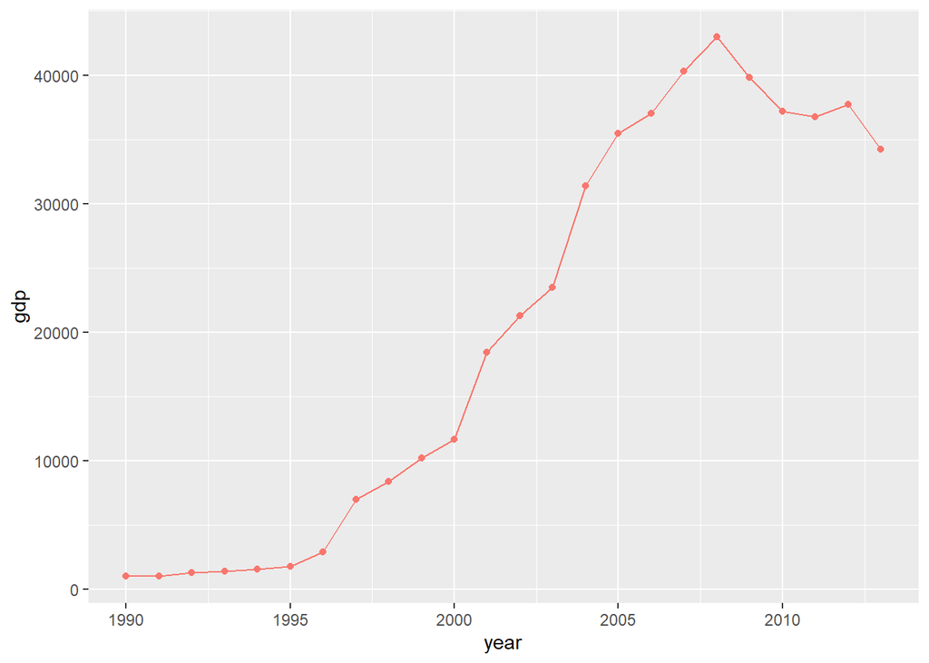

```r
fh5 %>%
  filter(country == "Equatorial Guinea") %>%
  ggplot(aes(x = year, y = gdp, color = country)) +
  geom_point() +
  geom_line() +
  theme(legend.position = "none")
```

## Visualization for Presentation

```r
fh6 <- fh %>%
  filter(year >= 1900) %>%
  group_by(year, continent) %>%
  summarise(child_mort = sum(child_mort))
```

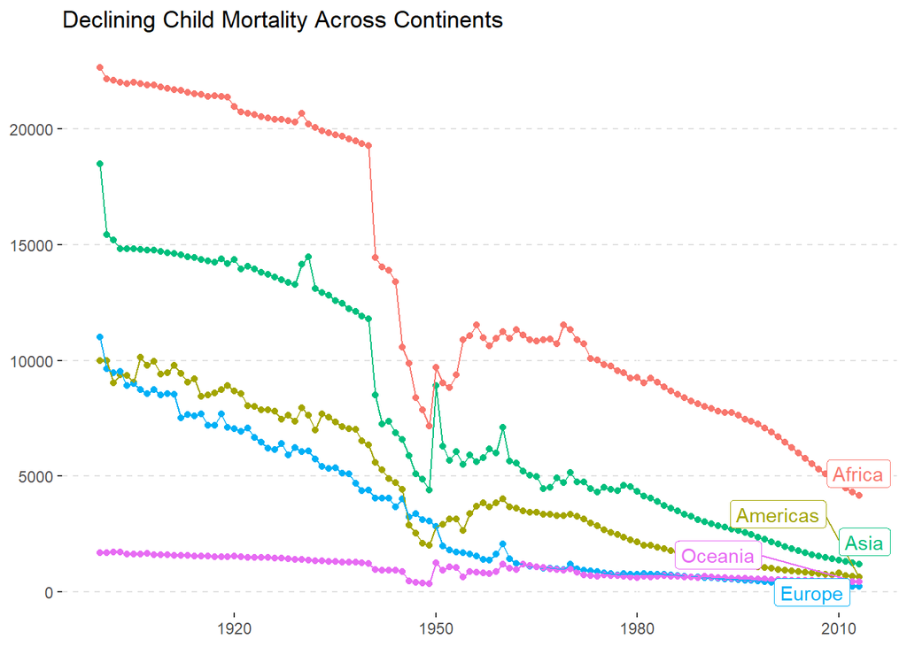

```r
label_points <- fh6 %>%
  group_by(continent) %>%
  filter(row_number(desc(year)) == 1)

ggplot(fh6, aes(x = year, y = child_mort, color = continent)) +
  geom_point() +
  geom_line() +
  theme(panel.background = element_blank(),
         plot.background = element_blank(),
         legend.position = "none",
         panel.grid.major.y = element_line(color = "grey88", linetype = "dashed"),
         axis.title = element_blank()) +
  geom_label_repel(data = label_points, aes(label = continent)) +
  labs(title = "Declining Child Mortality Across Continents",
       x = "Year")
```